# 交通量と交通事故死亡者数の関係

8BPE3224 利根諒太郎

2022/1/31

# 1.はじめに

なぜこのテーマを取り上げたのか？

交通量調査を実施している様子を見て、コロナ禍に外出量が減少したことで交通事故も減少しているだろうと思い、検証したくなったから。

## 2.仮説

本研究の仮説は以下のとおりである。

2020年はコロナ禍による自動車交通量や歩行者の外出の減少に伴い、交通事故が減った。また、緊急事態宣言も減少の要因となっている。

## 3.問題の背景

図表1より、自動車の交通量と事故死者数には正の相関があることが読み取れる。

```r
library(readxl)
library(ggplot2)
library(dplyr)
library(foreign)
library(stargazer)
traffic<-read_excel("koutsu.xlsx", sheet = 2)
```

```
## * `` -> ...1
```

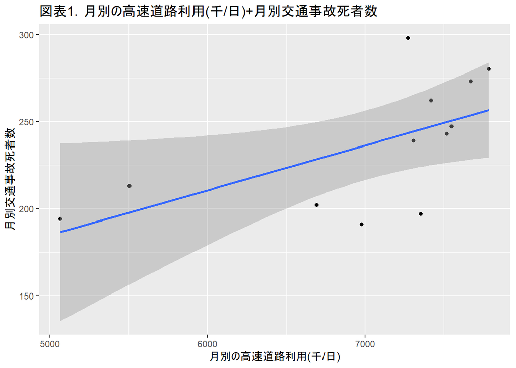

```r
#trafficresult<-lm(r2jiko~r2ryou, data = traffic)

# plot(traffic$r2ryou,traffic$r2jiko,main = "図表1．月別の高速道路利用(千/日)+月別交通事故死者数",xlab="月別の高速道路利用(千/日)",ylab="月別交通事故死者数")
 # abline(trafficresult)

traffic %>%
  ggplot(aes(x=r2ryou,y=r2jiko))+
  geom_point()+
  xlab("月別の高速道路利用(千/日)")+
  ylab("月別交通事故死者数")+
  ggtitle("図表1．月別の高速道路利用(千/日)+月別交通事故死者数")+
  stat_smooth(method = "lm")
```

## 4.分析

### 4.1 使用するデータの紹介

各高速道路会社の交通量データ - 独立行政法人 日本高速道路保有・債務返済機構 https://www.jehdra.go.jp/kousoku/kotu.html

警視庁 交通量統計表 https://www.keishicho.metro.tokyo.lg.jp/about_mpd/jokyo_tokei/tokei_jokyo/ryo.html

### 4.2 分析方法

1.平均の差の検定

2019年と2020年の月別交通事故死者数の平均の差の検定を実施した。

```r
t.test(traffic$r1jiko,traffic$r2jiko)
```

```
##
##  Welch Two Sample t-test
##
## data:  traffic$r1jiko and traffic$r2jiko
## t = 1.7726, df = 20.475, p-value = 0.09117
## alternative hypothesis: true difference in means is not equal to 0
## 95 percent confidence interval:
##  -5.484067 68.150734
## sample estimates:
## mean of x mean of y
##  267.9167  236.5833
```

### 4.3 分析結果

1.p-valueが95%の確率で0.05を上回っていることから帰無仮説を棄却することができず、2019年と2020年の月別交通事故死者数に差があるとはいえない。

## 5. 考察

交通事故の死者数にコロナ禍が関係しているとは言えなかった。

## 参考文献

各高速道路会社の交通量データ - 独立行政法人 日本高速道路保有・債務返済機構 https://www.jehdra.go.jp/kousoku/kotu.html

警視庁 交通量統計表 https://www.keishicho.metro.tokyo.lg.jp/about_mpd/jokyo_tokei/tokei_jokyo/ryo.html